# CS50 Assignment 2: Variables with LBA

## Part 1: Variable Selection [#variables]

Select a neighborhood in San Francisco. Visit this neighborhood and spend at least 30 minutes exploring the neighborhood to find your variable.

*Important notes:*

- The variable must be something that can be measured on each block in a specific 10+ block area. This means you need at least 10 different measurements (one for each block).
- You must be able to calculate the mean, median, mode, and standard deviation of the variable.
- Be clear about how your blocks are defined.
- Get creative! Try to choose an interesting and informative variable.

### 1.1 Define and operationalize your variable here. Describe how you selected your variable. Specifically identify the type of variable, and whether you will be measuring a total, proportion, or average. Also identify the units it will be measured in and explain in detail how you will measure it. Make sure that your explanation is clear enough that another student would understand how to make the same measurement. Give the address of the 10 or more blocks where you will conduct your measurement and provide an image that clearly identifies these blocks on a map. (<150 words)

The variable chosen is the number of Vietnamese and Thai restaurants per block in 11 blocks in the Tenderloin area. This is a discrete variable, measured on average of a block. They are discrete variable because there are finite number of Thai and Vietnamese restaurants per block, even if people open more and more, there is a capacity for these variables.

To collect the data, I have walked through the neighborhood and counted the number of variables in each block. The restaurants needed to sell Vietnamese and Thai food, excluding coffee shops. The maps below show the map of eleven blocks chosen.

(The blocks with "x" are the chosen ones.)

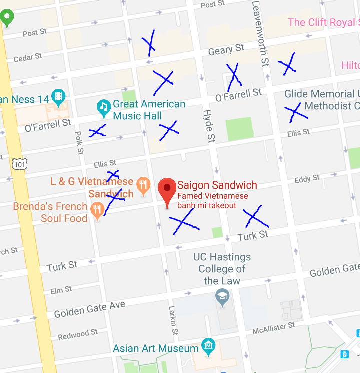

```python
from IPython.display import Image
Image ("map.png")
```

### 1.2.1 Describe a scenario in which your variable could be an independent variable. What could be the dependent variable(s)? What are some possible extraneous or confounding variables in this scenario? (<150 words)

The number of Thai and Vietnamese restaurants er block in Tenderloin could become an independent variable when we want to measure how this number affect the number of tourists from Asian countries visiting the area. In this case, the number of tourists from Asian countries is a dependent variable. The assumption is that as there are more restaurants per block, more Asian tourists will come to the neighborhood to enjoy their cultured dishes while traveling.

One possible extraneous variable in this scenario is that as Tenderloin is close to the Civic center where tourists often aggregate in, it might become a complete coincidence that tourists from Asian countries randomly appear more in the Tenderloin area only because of the area’s proximity to the Civic Center, not because of the restaurants.

Another confounding variable is that even though the existence of Thai and Vietnamese restaurants do play a strong role in attracting Asian tourists, the relatively bad reputation of Tenderloin discourages most of them to come to the area. Therefore, the density of Thai and Vietnamese restaurants per block in the area does not have any impact on the number of Asian restaurants visiting here.

### 1.2.2 Describe a scenario in which your variable could be a dependent variable. What could be the independent variable(s)? What are some possible extraneous or confounding variables in this scenario? (< 150 words)

The number of Thai and Vietnamese restaurants per block in the Tenderloin area could become a dependent variable when it changes according to the change of other parameters. In this case, one independent variable can be the number of tech companies. As more tech companies are established, there is an influx of tech employees into the city, which naturally leads to a higher number of customers for these restaurants. Thus, more people will be motivated to open more restaurants in the area to seize the promising market.

One possible extraneous variables in this scenario is that even though the number of tech companies in San Francisco increases massively, the number of people working in each company is small (three to four people) due to the nature of early startups, leading to the possibility that no more restaurants will be opened in the area because the demand does not increase significantly compared to before.

## Part 2: Estimation and Measurement [#estimation]

**Important note** If there is any reason to believe that you did not authentically complete the **location based** portion of this assignment, you will be referred to the ASC. Please follow the instructions here carefully and include the original photo files in the zip folder along with the ipynb.

### 2.1 Go to a Cafe in the neighborhood of your choice to produce a Fermi estimate of your variable. Use a napkin at a cafe to begin your Fermi estimate. You may not (yet) make any measurements. Your estimate should aim to involve at least 5 steps where you compute intermediate values. You will have to describe each step clearly, show your work, state any assumptions you’re making, and discuss whether your answer seems plausible (but it’s not necessary to do so on the napkin; see step 4 below).

### 2.2 Take some photos to document this experience. You must include:

1. A photo of your “back of the napkin” estimate (it can and should be quite rough at this point). You will properly format the calculation later.
2. A selfie in the cafe in which you constructed your Fermi estimate. Clearly show your face, your Fermi estimate, and some of the interior of the cafe.
3. A selfie outside of the cafe showing your face and the exterior of the cafe, including the name. Bonus points if you are also holding your completed Fermi estimate in the photo.

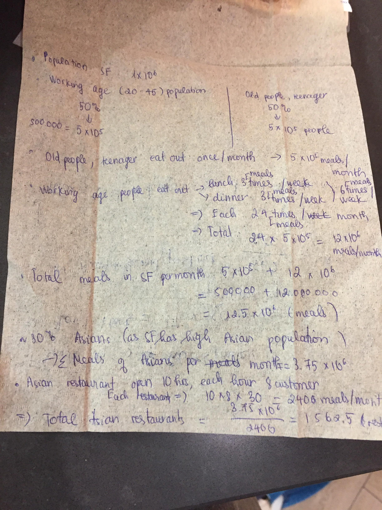

```python
from IPython.display import Image

Image("napkin1.jpg")
```

[figure not shown]

```python
Image("napkin2.jpg")
```

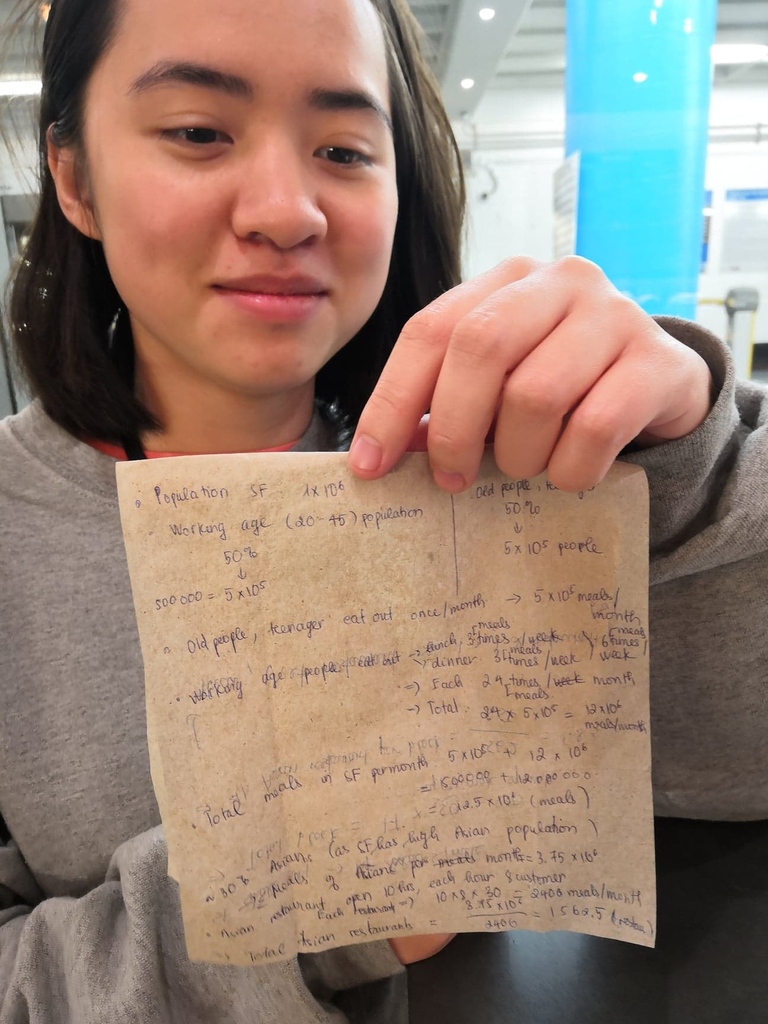

```python
from IPython.display import Image
Image("cafe1.jpg")
```

### 2.3 Typeset your full estimation in the Python notebook. Here, be sure to clearly explain all steps, justify all assumptions, and comment on whether the answer seems plausible.

# Fermi estimation for the number of Thai and Vietnamese restaurants per block in eleven blocks of Tenderloin area:

-There are roughly 1x10^6 people in San Francisco.

-This is a city with a high Asian population compared to other cities in the US, estimating 30%, so the Asian population in SF is 3x10^5. This estimation is carried out under the assumption that the major customers of Thai and Vietnamese restaurants are the Asian-ethnic population.

-Dividing this population into two groups equally. Working people will take up 1.5x10^5 people; old people and teenagers will take up the other 1.5x10^5 people. (50% - 50%) -Old people and teenagers usually do not have a considerable income to eat out so they go to Thai and Vietnamese restaurants once a month, making up 1.5x10^5 meals/month. -Working people have income so they eat out 3 times per week for lunch and 3 times per week for dinner per week, which is 24 times per month, making up 24*1.5x10^5 = around 25x10^5 meals/month. -In total, these two groups above make up: 25x10^5+1.5x10^5=26.5x10^5 meals/month. (A)

-To calculate the total number of Thai and Vietnamese restaurants, we need the number of meals per month sold by each restaurant on average. -Assuming each restaurant opens for 10 hours per day, each hour it has 10 customers, so there are 10*10*30 = 3x10^3 meals/month provided by each restaurant. (B) -The total number of Thai and Vietnamese restaurants in San Francisco = 26.5x10^5 / 3x10^3 = around 9x10^2 Thai and Vietnamese restaurants in San Francisco.

-To estimate the number of these restaurants per block, some information about the number of blocks is needed. Through looking from my own body build, I estimated that around 2000 people can fit into one block if they stand together in that block, given the population of 1x10^6 in SF, the total number of blocks in this city = 1x10^6/2x10^3=5x10^2 blocks. -Hence, the number of Thai and Vietnamese restaurants per block in the city = 9x10^2 / 5x10^2 = 1.4 restaurant/block. So on average, there are 1.4 restaurants/block in SF, which can be applied to the counted 11 blocks in Tenderloin area.

### 2.4 It’s time to collect your data! Once again, take some photos to document your experience. Include at least two photos of your variable collection process. At least one photo should include your face and the variable you are counting.

[figure not shown]

```python
Image("sandwich1.jpg")
```

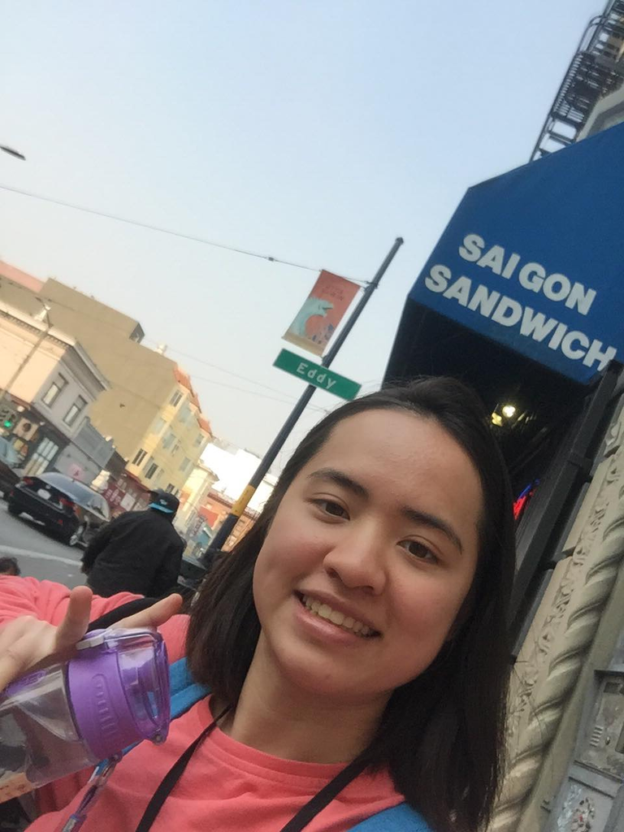

```python
from IPython.display import Image

Image("sandwich2.jpg")
```

## Part 3: Analysis

### 3.1 Analyze the data in Python [#algorithms]:

### 3.1.1 Use any method to import your collected data into Python. You can simply type the data directly into a Python list or numpy array. Or, you can put the data in a Google sheet, export to a .cvs file, and import into Python. Print your data here.

```python
asian_goodies = [4,5,1,1,1,2,2,1,1,1,4]
print (asian_goodies)
```

```
[4, 5, 1, 1, 1, 2, 2, 1, 1, 1, 4]
```

### 3.1.2 Using Python, calculate the mean, median, mode, range, and standard deviation of your variable. Print these values. If you use a library function, you need to explain how it works with detailed comments. Do not blindly use library functions!

```python
asian_goodies = [4,5,1,1,1,2,2,1,1,1,4]

#Find mean:
def mean(asian_goodies):
    return float(sum(asian_goodies)) / len(asian_goodies)
#represent the formula of mean with python syntax
print ("Average =",mean(asian_goodies))

#Find median:
def median(asian_goodies):
    n = len(asian_goodies)
    if n < 1:
#if there is no variable in the list, there is no median
            return None
    if n % 2 == 1:
#if the remainer of the number of variables divided by 2 is 1 or is an odd number
            return sorted(asian_goodies)[n//2]

    #sort the list from small to large
    #the median is the number on the position correlates to n//2 in the last
    #For example if n//2=2, then the median is the 2nd number in the list
    #counting from 0 (Python rule)
    else: #if the number of variables divided by 2 or is an even number
            return sum(sorted(asian_goodies)[n//2-1:n//2+1])/2.0
        #the median will be equal to the average of two numbers
        #that have position (n//2-1) and (n//2+1)
print ("Median =",median(asian_goodies))


#Find mode:
from scipy import stats #import the library to use its function
mode_restaurants = stats.mode(asian_goodies)[0][0]
#[0][0] to choose the first number of the first list
print("Mode =",mode_restaurants)

#Find range:
def range(asian_goodies):
    return max(asian_goodies) - min(asian_goodies)
print ("Range =",range(asian_goodies))


#Find Standard deviation:
import numpy
import scipy

stddev = 0
average = 0
average = numpy.mean(asian_goodies)
diffsquared = 0
sum_diffsquared = 0
for val in asian_goodies:
  diffsquared = (val-average)**2
  sum_diffsquared = diffsquared + sum_diffsquared
stddev = ((sum_diffsquared)/len(asian_goodies))**0.5
print("Standard deviation =",stddev)
```

```
Average = 2.090909090909091
Median = 1
Mode = 1
Range = 4
Standard deviation = 1.443137078762504
```

### 3.1.3 Create a histogram for your data, properly formatting your figure.

[figure not shown]

```python
import matplotlib.pyplot as plt
plt.hist(asian_goodies, 12, edgecolor = 'k')
plt.title("Thai and Vietnamese restaurants per block in 11 blocks in Tenderloin")
plt.xlabel("Number of restaurants")
plt.ylabel("Frequency")
plt.show()
```

### 3.2 Interpret the descriptive stats: What can you say about the neighborhood based on these values? Is the distribution skewed? Is your visualization in agreement with the descriptive statistics? Explain. [#dataviz, #descriptivestats] (<200 words)

From this graph, it can be implied that the distribution of Vietnamese and Thai restaurants in these eleven blocks in Tenderloin is not dense with one restaurant per block frequently. On the other hand, the existence of these restaurants is prevalent enough to create a neighborhood that is well-known for Asian food in general due to the small size of the neighborhood.

## Part 4: Probability Considerations [#probability, #algorithms, #simulation]

### 4.1 Can the mean of your data be interpreted as the expected value of a random variable? Explain why or why not in detail. (~50 words)

The mean of the data is also the expected value of Thai and Vietnamese restaurants per block in 11 blocks in Tenderloin. To calculate the mean, we sum up all random variables and divide that by the number of variables. Essentially, it is the same as multiply the variable with the probability of it appearing in the sample space of all the variables because the expected value can be thought of as the arithmetic mean of a set of numbers generated in exact proportion to their probability of occurring.

### 4.2.1 Suppose something unfortunate happened: you stole too many napkins for your Fermi estimate, so you decided to write all of your variable measurements on separate napkins, one napkin for each block. On your way back to res, the wind picked up and blew them all away! Luckily, you managed to collect all of the napkins, but now the data is totally randomly reordered, meaning that you have no idea which napkin corresponds to which block. Suppose that you tried to just guess randomly which napkin goes with which block. In other words, you randomly assign each napkin to a given block.

### What is the probability that you are unlucky, and sadly NONE of the napkins are matched to the correct block (you guessed all of them wrong)? Estimate this probability using a simulation. Be sure to interpret the result appropriately. See hints below.

```python
import random
import numpy as np
napkins = [0,1,2,3,4,5,6,7,8,9,10]
simulation_times = 1000
count = 0 #before iterating, there is no incorrect matching, so count=0

for i in range(simulation_times):
  rand_napkins = np.random.choice(napkins,11,replace=False)
#select from napkin list 11 elements
#and not replace duplicate
  matched = False
  for k in range(11): #For k in the range of 11 elements
      if rand_napkins[k] == napkins[k]:
#if all the napkins are matched to the correct blocks (similar elements from each list)
          matched = True
#it means that there is at least one napkin that is matched to the correct block
          break
#use this to terminate the loop because this is not what we are looking for
      else: #if there is it least one matched element
          pass #we pass and continue to iterate
  if matched == False:
#if there is no matching between two lists rand_napkins and napkins
      count = count + 1 #we add one into the number of incorrect matching
print("Probability that none of the napkins are matched=",count/simulation_times)
```

```
Probability that none of the napkins are matched= 0.366
```

### 4.2.2 *Optional*: What is the expected number of napkins that will be correctly matched to the corresponding block? Estimate this probability using a simulation and interpret the result appropriately.

```python
# 4.2.2 Edit this cell to include your code for 4.2.2
```

4.2.2 Edit this cell to explain your solution

### 4.2.3 *Optional*: Determine the probability distribution as a function of the number of correctly matched napkins and create a visualization.

4.2.3 Edit this cell to answer 4.2.3

```python
# 4.2.3 Edit this cell to include your code for 4.2.3
```

### 4.2.4 *Optional*: Compute the probability or expected value found above or both *analytically* (without a simulation).

4.2.4 Edit this cell to answer 4.2.4

### **Hints**:

- To simplify the problem, you can disregard your actual variable data if you wish, and simply make a new list in Python consisting of the numbers 0 through 9: `napkins = [0,1,2,3,4,5,6,7,8,9]`. Pretend that this is your stack of napkins with the variable measurements in the correct order. Notice that this data satisfies `napkins[i] == i`, for all values of `i` from 0 to 9. Think of the index i as the block label.
- A random permutation of this list can be created with the following code: `rand_napkins = np.random.choice(napkins,10,replace=False)`. You should be able to explain how this function works and why it is relevant for the problem.
- You want to check whether `rand_napkins[i] == i`, for each value of `i` from 0 to 9. You’ll need to use a loop to create many random lists and repeat the checking procedure, keeping track of the number of matches each time.

## Part 5: Reflection

Reflect on what you learned about the HCs in this assignment, focussing on the connections between the HCs, and their connections to the city. Also reflect on how your prediction and estimation from parts 1 and 2 compare to the results. (<200 words)

My favorite part is definitely Fermi #estimation as it turns out to be powerful in the variables I have chosen. Also, my takeaway is that it is always helpful to know the population of the country or city I am living it, which can be applied to Minerva's further rotation.

The most challenging part is #probability #simulation because I have to think thoroughly in Math and translate it into Python language. I have spent a big amount of time on part 4 and at the point where I almost gave up, it worked! I need to spend more time doing #algorithms for further advancement.

# You're ready to submit your assignment!

To submit, you need to save this file in two ways.

1. As an .ipynb Notebook
2. As a PDF

For both files, simply go to `File/Download as` ... and select the appropriate file type. To upload to ALF, submit **both** your .ipynb Notebook in a zipped folder and the PDF.

If you have trouble with with downloading the file as PDF, refer to this [document](https://docs.google.com/document/d/1gRMol9Ebbvyu1mvEKzma92o_N7ZbNXsPIb1QdQV0TeE/edit?usp=sharing)